# LT5 - Final Project Report

```python
from IPython.display import HTML

HTML('''<script>
code_show=true;
function code_toggle() {
 if (code_show){
 $('div.input').hide();
 } else {
 $('div.input').show();
 }
 code_show = !code_show
}
$( document ).ready(code_toggle);
</script>
<form action="javascript:code_toggle()"><input type="submit"
value="Click here to toggle on/off the raw code."></form>''')
```

```python
from IPython.core.display import HTML
HTML("""
<style>
.output_png {
    display: table-cell;
    text-align: center;
    vertical-align: middle;
}
</style>
""")
```

```python
import pandas as pd

import matplotlib.pyplot as plt
%matplotlib inline
import matplotlib.image as mpimg
import seaborn as sns
sns.set_style("whitegrid")
```

[figure not shown]

**Tiny Plastic, Big Problem!**

**Microplastics Detection with Deep Learning**

**Gaspar | Jayme | Nepomuceno | Paderes**

# Executive Summary

Background

Each week, humans consume around 2,000 tiny pieces of plastic each week—an amount equivalent to the weight of one credit card—because of microplastic particles floating in surface waters worldwide. Its small dimensions enabled it to be fluid-like and be suspended in water or even air, making it a challenge for researchers and environmentalists to isolate, detect, and measure. Digital holographic microscopy has been proposed to detect microplastics while being non-invasive, non-contact, and low-cost. However, it remains time-consuming and requires resource-intensive image preprocessing. The authors propose the use of YOLOv5, the latest version of the "You Only Look Once," a state-of-the-art object detection algorithm, to rapidly detect and count microplastics from hologram images.

Methods

Results

With a batch size 16 and with 500 epochs, the best model yielded an mAP of 90.5% for detecting and counting plastics. The resulting inference time is a small fraction of a second, at 0.007 seconds, enabling the model to detect plastics and dust even at the edges of the frame and despite partial occlusion between objects.

Conclusion and Recommendations

In successfuly demonstrating the use of YOLOv5 as a tool that can reliably count and classify microplastic in hologram images, the authors showed that using a deep learning model like YOLOv5 can aid in automating feature extraction and hastening the classification of hologram images. The short inference time and low file size potentially enables researchers and environmentalists alike to use this model in situ given recent innovations in portable hologram imaging devices. The implementation can be developed further by including the type of microplastic in the annotations and using video samples to enable the detection of objects under digital holographic microscopes in real-time.

# 1. Introduction

## 1.1. Background

The huge problem of plastic waste in the oceans have become even more concerning because of the large-scale generation of microplastics. This introduces new levels of danger and risks for both marine organisms and humans which scientists are only beginning to quantify and understand. It is estimated that there are 15 to 51 trillion microplastic particles floating in surface waters worldwide, with 14 million tons worth of plastic being added to the oceans every year (Lim, 2021). These are generated from large plastic particles when it experiences natural weathering while floating in the oceans. Weathering occurs through UV radiation and mechanical tearing due to the strong ocean waves and winds. As a result, these microplastics become smaller and smaller in size until they become microplastics (Lavoie, Boulay, & Bulle, 2021).

Microplastics are officially defined as plastic particles that has a maximum dimension of 5 mm or less. The term was coined in 2004 by Richard Thompson, a marine ecologist at the University of Plymouth, UK. Ever since, scientists have been discovering microplastics virtually everywhere—in the deep oceans, in the Arctic snow and Antarctic ice, in the air, and in everyday household items like drinking water and table salt (Hershberger, 2020). In fact, some studies suggest that we ingest about 2,000 tiny pieces of plastic each week, an amount equivalent to the weight of one credit card. The microscopic dimensions of these particles have enabled them to be fluid-like and be suspended in water or even air without quick settling. This makes microplastics harder to isolate and detect.

The dangers of microplastics are more documented and studied for marine organisms because of the tendency of generated microplastics to be eventually washed up in rivers and oceans. Zooplanktons, one of the primary food sources at the bottom of the food web, have been mistaking these microplastics for food particles due to their color and size. As a result, these organisms are not getting the right nutrition to survive, thereby affecting the next levels of the food web. Larger fish and other marine organisms experience a similar fate and since humans consume fish, their ingested microplastics pass on to us (Lim, 2021).

For humans, the risks of microplastic ingestion and inhalation are still ongoing careful assessment by scientists and medical professionals. Nevertheless, current studies suggest that ingestion may cause physical and chemical damage to our organ systems because of its ability to infiltrate tissues and, in some cases of nanoplastics, even cells. Microplastics can also be toxic and hazardous due to the other chemical compounds that are usually integrated in the manufacturing process of plastics like stabilizers and surfactants (Campanale, Massarelli, Savino, Locaputo, & Uricchio, 2020).

### 1.1.1. Microplastic Pollution Monitoring Methods

**FIGURE 1: Diagram of a Digital Holographic Imaging System ([Merola, et al., 2018](#merola))**

[figure not shown]

Microplastic monitoring methods aim to estimate the level of microplastic pollution in the surroundings. Due to the severity of its effect on marine organisms, most documented methods center on microplastics collected from bodies of water. The level of pollution is measured by getting the concentration of microplastics in a body of water. The concentration of microplastics can be indicated by the number of microplastic particles in a known volume of water. However, counting is made difficult by the presence of other materials like glass, sand, or dust that might share the same visual characteristics with microplastics.

Of all the current methods used to detect microplastics, digital holographic microscopy (DHM) is the imaging method most associated with studies that attempt to automate classification of microplastics with machine learning techniques. This is because hologram images offer more 3D information than conventional 2D images, thereby enabling more relevant feature extraction and efficient performance in classification tasks (Lam, 2018). Outside of machine learning, DHM is still a popular imaging system among researchers because it is non-invasive and non-contact, making it suitable for underwater imaging (Merola, et al., 2018). Lastly, it is compact and low-cost versus other imaging methods like scanning electron microscopy (or SEM for short).

However, current DHM workflows still require time-consuming and possibly resource-intensive image pre-processing for feature extraction, such as denoising and reconstruction. Moreover, analysis and classification tasks are still highly dependent on subject matter experts, leading to slower cycle times for analysis (Zhu, Yeung, and Lam (2021)). Multiple studies have explored both traditional machine learning and deep learning techniques for classifying images based on microplastic count. One study designed a custom CNN they called HC-CNN that could classify a hologram as having no microplastics, having a single microplastic and so on up to five and more microplastics based on a raw holographic image (Zhu, Yeung, and Lam (2021)). The same group of researchers also studied using YOLO-LITE, an object detection algorithm, to work with raw holographic images (Zhu, Yeung, and Lam (2020)). However, that study only worked with Low-Density Polyethylene (LDPE) microplastics and failed to detect particles that were only at the edges of the image and are only partially visible.

### 1.1.2. YOLOv5

**FIGURE 2: Overview of How YOLO Works ([Redmon, Divvala, Girshick, & Farhadi, 2016](#redmon))**

[figure not shown]

YOLO, short for "You Only Look Once," is an object detection algorithm that works by dividing an image into grids. It is a popular state of the art algorithm for this task due to its speed and accuracy. It is also known to work well with video data and real-time detections. The latest version of YOLO is YOLOv5, which was publicly launched by Ultralytics last June 2020. YOLOv5 is written with PyTorch and is open source with 58 contributors.

The value of YOLO algorithms lies in its combination of multi-step processes of classification and prediction of bounding boxes into a single neural network. It looks at the entire input image once, which enables it to capture the context of the objects with the surroundings, contrary to another detection model, namely region-based CNN's (R-CNN's), which looks at different image parts separately (Aggarwal, 2020). FIGURE 2 shows a high-level overview of how YOLO algorithms work.

**FIGURE 3: YOLOv5 Network Architecture ([Xu, Lin, Lu, Cao, & Liu, 2021](#xu))**

[figure not shown]

FIGURE 3 shows the network architecture of YOLOv5. It is divided into three sections: (1) the backbone (CSPDarknet), (2) the neck (PANet), and (3) the head (Yolo Layer). The data is first supplied into CSPDarknet, which extracts features, and then into PANet, which fuses them. Finally, the YOLO Layer gives the results of the detection (i.e., class, score, location, and size).

For this study, the same architecture implemented by the author Glenn Jocher for training on COCO dataset was used; that is, no changes were made on the network. Only a few minor tweaks were made, such as changing the font size and label names. These tweaks were made in `detect.py` and `utils.py` files.

## 1.2. Motivation and Impact

The success of this project will help researchers and environmental organizations monitor microplastic pollution in their local areas more effectively and efficiently than before. The presence of a high-accuracy and high-speed detection model will hasten analysis of microplastic pollution levels across different points of a body of water and across different points in time. The shorter cycle time between sample collection, image capturing, and image analysis will enable better allocation of limited resources that could allow for more sample collection and, subsequently, more data points.

Ultimately, a more accurate and consistent measure of the pollution levels will help in pushing for actions and policies that will mitigate microplastic pollution. These actions are envisioned to be at more appropriate levels of urgency and resource allocation than existing ones, owing to the greater data quality that could be supplied from this project.

## 1.3. Problem Statement

In this study, the authors wanted to improve the currently existing DHM workflows on microplastic pollution monitoring by removing tedious image preprocessing steps and by automating object detection, classification, and counting. To do this, YOLOv5 was used to automatically distinguish and count microplastics from a raw hologram image that may or may not contain dust particles.

In terms of novelty, the authors aimed to build on previously explored deep learning approaches by expanding the types of microplastic that the model is trained on and incorporating object counting aside from detection.

## 1.4. Scope and Limitations

Lastly, no subject matter expert on microplastics or holographic images were consulted for this project. Manual annotation of bounding boxes were performed by using the corresponding ground-truth labels provided and inferring which particles are plastic or not. The microplastic and dust particles were manually distinguished by studying the microplastic features in the images that have no dust particles.

# 2. Data Source

## 2.1 Data Description

The dataset consists of images of microplastics taken with a digital in-line holography system and made open source by Zhu, Yeung, and Lam (2020) through [their GitHub repository](https://github.com/ymzhu19eee/dataset_microplastics). The images include polyethylene (PE), polystyrene (PS), low-density polyethylene (LDPE), and high-density polyethylene (HDPE), with samples ranging from 90 to 450 micrometers (µm) in size. All samples were prepared by a third-party professional.

The following modifications were made on the dataset:

1. Zhu, Yeung, and Lam (2021) labelled all images with the aforementioned four types of plastic. The first number in the filename corresponds to the number of microplastic particles in the image. Due to lack of domain expertise in the team, all microplastic particles were simply labelled as `plastic` regardless of type instead of distinguishing one type of plastic from another.
1. Zhu, Yeung, and Lam (2021) similarly included a `mixed` folder where they combined different types of plastic per hologram image. For the same reason as #1, the images in this folder were not included due to lack of domain expertise. Specifically, the team was unable to distinguish `dust` and other artifacts from actual `plastic` in the image.

These modifications were done to be consistent with the problem statement for this project, that is, to detect and count the number of microplastics in an image.

## 2.2. Summary Statistics

A total of 1,091 objects were annotated with 1 of 2 classes (i.e., `plastic` and `dust`) across 472 images available in the dataset.

**TABLE 1: Summary of the Dataset**

| Images | 472 |
| --- | --- |
| Null examples | 36 |
| Annotations | 1,091 |
| Average annotation per image | 2.3 |
| Average image size in megapixels | 5.07 |
| Median image ratio | 2456 × 2056 |

The dataset is imbalanced in favor of `plastic`. It is important to note that the objective of the project is to identify and count `plastic`s instead of `dust`.

**TABLE 2: Class Balance**

| Particle Type | Count | % of Total |
| --- | --- | --- |
| Plastic | 864 | 79% |
| Dust | 227 | 21% |
| Total | 1,091 | 100% |

# 3. Methodology

## 3.1. Computational Requirements

This project was implemented using a notebook in Google Colab Pro with a Tesla P100 GPU and 16 GB in RAM. However, only 1.34 GB was required, most likely due to the type of YOLO employed, specifically YOLOv5s which is the smallest and most lightweight version of YOLO to date. Total training time under YOLOv5s required only 1.409 hours for 500 epochs, at around 10 seconds per epoch.

## 3.2. Importation of Libraries

YOLOv5 was cloned from [Ultralytics’ current Github repository](https://github.com/ultralytics/yolov5). All required dependencies were installed.

**Code used:**

```
# install dependencies as necessary
%cd yolov5
!pip install -qr ./requirements.txt                # install dependencies (ignore errors)

import torch
from IPython.display import Image, clear_output    # to display images

# clear_output()
print('Setup complete. Using torch %s %s' % (
    torch.__version__,
    torch.cuda.get_device_properties(0) if torch.cuda.is_available() else 'CPU'))
```

## 3.3. Data Retrieval

The data was retrieved from an open-source dataset provided by Zhu, Yeung, and Lam (2020) in [their GitHub repository](https://github.com/ymzhu19eee/dataset_microplastics). The dataset was uploaded onto the `/content` folder in Google Colab. Details on the modifications done for this project are provided in the "Dataset Description" section of this report.

## 3.4. Data Annotation

The images were annotated using Roboflow, a platform that allows division of annotation tasks among a group of people. Each team member received a set of images with an 80-10-10 training-validation-test split for annotation.

**FIGURE 4: Screenshot of an Annotation in Roboflow**

[figure not shown]

Each team member annotated all hologram images from scratch by uploading it to the website and drawing bounding boxes around the objects. The classes were assigned using the ground-truth labels provided in the file name of each image. Each image was resized to 416 × 416 following the default size for YOLOv5.

## 3.5. Data Augmentation

The augmentations were performed within the Roboflow platform, wherein the following were applied randomly across all images:

- 50% probability of horizontal flip
- 50% probability of vertical flip
- Random rotation of between -15 and +15 degrees
- Random shear of between -15° to +15° horizontally and -15° to +15° vertically

The above augmentations were selected based on usual changes that affect images when items are placed under a hologram microscope. Augmentations that will not contribute to improvements on the model, such as zooming in, were intentionally left out. As each training image is augmented, Roboflow produced three variants for the training set following the entered augmentation parameters, essentially triplicating the number of training images in the dataset.

Roboflow also allows for easy exporting to the required YOLOv5 PyTorch format, which requires TXT annotations and YAML configuration. A total of 1,228 images were included in the training, validation, and test sets.

The dataset was imported using the `roboflow` library and its API.

**Code used:**

```
# install roboflow
!pip install -q roboflow

from roboflow import Roboflow

rf = Roboflow(model_format="yolov5", notebook="roboflow-yolov5")
rf = Roboflow(api_key="********************")
project = rf.workspace("<username>").project("microplastics-2")
dataset = project.version(1).download("yolov5")
```

After running the above codes, the dataset should be in `./yolov5/microplastics-2-1`.

## 3.6. YOLOv5 Model Training

YOLO, an object detection algorithm, was used to detect microplastics in the images. This algorithm works by dividing an image into regions and predicting bounding boxes.

The hyperparameters listed in TABLE 3 were used in training the model; YOLOv5s, the smallest version of YOLOv5, was used. The default values were used for most of the hyperparameters, and changes were made primarily to the number of batch sizes and epochs. After several iterations, `16` and `500`, respectively, were selected as the values of these hyperparameters since these yielded the best results.

**TABLE 3: List of Hyperparameters and Their Corresponding Values**

| Hyperparameter | Value |
| --- | --- |
| Model | YOLOv5s |
| Image size | 416 × 416 |
| Optimizer | SGD |
| Batch size | 16 |
| Learning rate | 0.001 |
| Momentum | 0.937 |
| Weight decay | 0.0005 |
| Warmup epochs | 3.0 |
| Warmup momentum | 0.8 |
| Warmup bias learning rate | 0.1 |
| `box` | 0.05 |
| `cls` | 0.5 |
| `cls_pw` | 1.0 |
| `obj` | 1.0 |
| `obj_pw` | 1.0 |
| `iou_t` | 0.2 |
| `anchor_t` | 4.0 |

Note that the hyperparameter `iou_t` is the IoU threshold the YOLOv5 model uses for determining True and False positives. For model training, this was set to its default value of 0.2. This means that if a model prediction yields any IoU value higher than 0.2, then the model will classify the prediction as a True Positive (TP). Similarly, if a model prediction yields any IoU value lower than 0.2, then the model will classify the prediction as a False Positive (FP).

To see the model training performed by the team, please refer to the notebook `01_Training.ipynb` that accompanies this report.

## 3.7. YOLOv5 Model Evaluation

The relevant metrics were then printed for model evaluation. The results are plotted and discussed further in the "Results and Discussion" section below.

The best and last weights are saved in the folder `./yolov5/runs/train/weights`. The best weights were used to produce images for visual inspection (please refer to the support notebook `01_Training.ipynb` to view these images).

Finally, the best model was saved as `best.pt`. This yielded a file size of only 14.1 MB and an inference time of around 0.007 seconds.

# 4. Data Exploration

FIGURE 5 presents samples from the annotations created by the team. Note that some of the objects are at the edges of the image, but the annotations for these objects were retained.

**FIGURE 5: Ground-truth Training Data**

[figure not shown]

As previously stated, augmentations were done through Roboflow; these are shown in FIGURE 6. Classes `0` (marked by blue boxes) and `1` (marked by orange boxes) refer to `dust` and `plastic`, respectively.

**FIGURE 6: Ground-truth Augmented Training Data**

[figure not shown]

Heatmaps of the position of annotations were plotted through Roboflow to see whether the position of microplastic and dust particles are evenly distributed across images. As can be seen in FIGURE 7, microplastic particles are distributed across almost the entire image. Moreover, the heatmaps in FIGURES 7 and 8 imply that dust particles have irregular shapes and rough edges while microplastic particles are smoother and have more symmetric shapes.

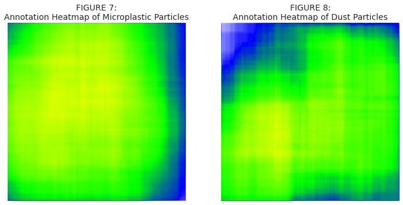

```python
fig, axes = plt.subplots(1, 2, figsize=(12, 6))

axes[0].imshow(mpimg.imread("figures/fig7.png"))
axes[0].set_title("FIGURE 7:\nAnnotation Heatmap of Microplastic Particles",
                  fontsize=14)
axes[1].imshow(mpimg.imread("figures/fig8.png"))
axes[1].set_title("FIGURE 8:\nAnnotation Heatmap of Dust Particles",
                  fontsize=14)

for i in range(2):
    axes[i].axis("off")

plt.show()
```

# 5. Results and Discussion

To the knowledge of the authors, this is the first application of YOLOv5 to hologram images of microplastics. The usual metric for object detection is the **mean average precision (mAP)**: It compares the bounding boxes of the ground truth (i.e., the annotated boxes) and the detected boxes.

**TABLE 4: Metrics**

| Class | Precision | Recall | `mAP\@0.5` | `mAP@[0.5:0.95]` |
| --- | --- | --- | --- | --- |
| **Plastic** | **0.906** | **0.908** | **0.905** | **0.578** |
| Dust | 0.773 | 0.850 | 0.758 | 0.410 |
| All | 0.839 | 0.879 | 0.831 | 0.494 |

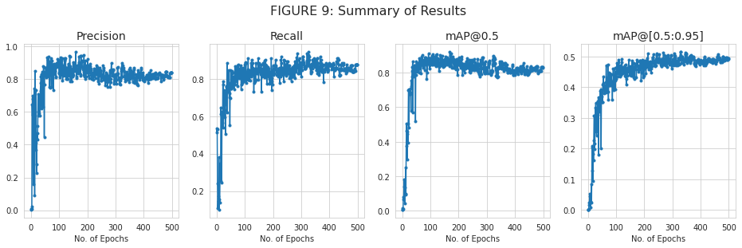

```python
df = pd.read_csv('results.csv')

fig, axes = plt.subplots(1, 4, figsize=(16, 4))

col_names = ['precision', 'recall', 'mAP@.5', 'mAP@.5:.95']
plot_titles = ["Precision", "Recall", "mAP@0.5", "mAP@[0.5:0.95]"]

for i in range(4):
    axes[i].plot(df[col_names[i]], marker=".")
    axes[i].set_title(plot_titles[i], fontsize=14)
    axes[i].set_xlabel("No. of Epochs")

fig.suptitle("FIGURE 9: Summary of Results", fontsize=16, y=1.05)

plt.show()
```

The best model is then run with the test set to evaluate its performance.

The model takes only a small fraction of a second to detect microplastics given a new image, with an inference time of approximately 0.007 seconds. FIGURE 10 presents a number of images that were produced by the best model for the test set. Each image provides the confidence level of its object classification.

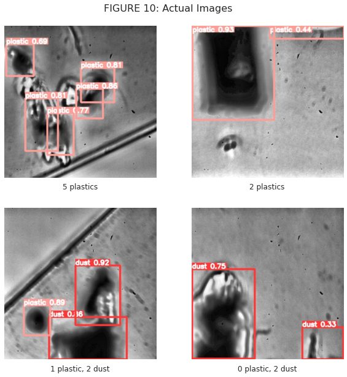

```python
fig, axes = plt.subplots(2, 2, figsize=(10, 10))

img_paths = ["figures/fig10a.png",
             "figures/fig10b.png",
             "figures/fig10c.png",
             "figures/fig10d.png"]
plot_titles = ["5 plastics",
               "2 plastics",
               "1 plastic, 2 dust",
               "0 plastic, 2 dust"]

for k in range(4):
    i, j = divmod(k, 2)
    axes[i][j].imshow(mpimg.imread(img_paths[k]))
    axes[i][j].set_title(plot_titles[k], y=-.1)
    axes[i][j].axis("off")

fig.suptitle("FIGURE 10: Actual Images", y=.93, fontsize=16)
plt.show()
```

For example, the upper-right image indicates that the model is 93% and 44% confident that the two objects are microplastic particles. In the lower-right image, the model correctly did not classify any particle as a microplastic. Finally, in the upper-left image, the model distinguished the microplastic particles with high confidence levels despite partial occlusion.

Other images of the test set are included in `./yolov5/runs/detect/exp` for reference.

# 6. Conclusion

In this report, YOLOv5 was successfully demonstrated as a tool that can reliably count and classify microplastics in hologram images.

Digital holographic microscopy is low-cost and provides particle shape information that improves accuracy of classifications, and the YOLOv5 model described in this report advances these advantages further by using deep learning to automate feature extraction and hasten the classification of hologram images. The short inference time and low file size have the potential to enable researchers and/or environmentalists to use this model in situ given recent innovations in portable hologram imaging devices.

Ultimately, the authors hope that this project contributes to the improvement of measurement of microplastic levels in our oceans to support appropriate actions and policies that should be put in place to mitigate this environmental disaster.

# 7. Recommendations

The following are recommendations to other researchers who wish to extend and/or improve the implementation of YOLOv5 in detecting microplastic particles:

1. **Annotate images with the type of microplastic particle.** Plastics have different levels of toxicity (i.e., some types are simply inert while others are toxic when broken down). Thus, differentiating the type of microplastic particles in image annotations should provide more novel insights in determining, for example, the level of concentration or toxicity in each sample.
1. **Consult domain experts when annotating images.** Inexperienced researchers may find the many types of microplastics challenging and overwhelming. Consulting domain experts in image annotations will ensure that the classification of microplastic particles is correct; they can also provide more nuance on related information such as the toxicity of different plastic types.
1. **Use video samples.** YOLOv5 is adept in accepting video inputs to detect and classify objects in real-time. It is thus possible to integrate YOLOv5 with imaging devices to detect the types of microplastics and other artifacts in real-time.

# 8. References

Aggarwal, A. (2020, December 28). YOLO Explained. *Medium.* https://medium.com/analytics-vidhya/yolo-explained-5b6f4564f31

Campanale, C., Massarelli, C., Savino, I., Locaputo, V., & Uricchio, V. F. (2020). A detailed review study on potential effects of microplastics and additives of concern on human health. *International Journal of Environmental Research and Public Health*, *17*(4). https://doi.org/10.3390/ijerph17041212

Hershberger, S. (2020, June 11). Thousands of Tons of Microplastics Are Falling from the Sky. *Scientific American.* https://www.scientificamerican.com/article/thousands-of-tons-of-microplastics-are-falling-from-the-sky/

Lam, E. (2018). Computational imaging and reconstruction in digital holographic microscopy. *Biomedical Imaging and Sensing Conference*, *10711*, p. 1071104). https://doi.org/10.1117/12.2315322

Lavoie, J., Boulay, A. M., & Bulle, C. (2021). Aquatic micro‐ and nano‐plastics in life cycle assessment: Development of an effect factor for the quantification of their physical impact on biota. *Journal of Industrial Ecology*. https://doi.org/10.1111/jiec.13140

Lim, X. (2021, May 4). Microplastics are everywhere—but are they harmful? *Nature.* https://www.nature.com/articles/d41586-021-01143-3

Merola, F., Memmolo, P., Bianco, V., Paturzo, M., Mazzocchi, M. G., & Ferraro, P. (2018). Searching and identifying microplastics in marine environment by digital holography. *The European Physical Journal Plus*, *133*(9). https://doi.org/10.1140/epjp/i2018-12190-y

Redmon, J., Divvala, S., Girshick, R., & Farhadi, A. (2016). You only look once: Unified, real-time object detection. *2016 IEEE Conference on Computer Vision and Pattern Recognition (CVPR)*, pp. 779-788. https://doi.org/10.1109/CVPR.2016.91

Xu, R., Lin, H., Lu, K., Cao, L., & Liu, Y. (2021). A forest fire detection system based on ensemble learning. *Forests*, *12*(2). https://doi.org/10.3390/f12020217

Zhu, Y., Yeung, C. H., & Lam, E. Y. (2020). Automatic detection of microplastics by deep learning enabled digital holography. *Imaging and Applied Optics Congress*, The Optical Society (Optica Publishing Group, 2020). https://doi.org/10.1364/DH.2020.HTu5B.1

Zhu, Y., Yeung, C. H., & Lam, E. Y. (2020). Holographic classifier: Deep learning in digital holography for automatic micro-objects classification. *2020 IEEE 18th International Conference on Industrial Informatics (INDIN)*, pp. 515-520. https://doi.org/10.1109/INDIN45582.2020.9442146

Zhu, Y., Yeung, C. H., & Lam, E. Y. (2021). Microplastic pollution monitoring with holographic classification and deep learning. *Journal of Physics: Photonics*, *3*(2). https://doi.org/10.1088/2515-7647/abf250